# Practical 2 - Conjugacy, prediction and Monte Carlo simulation

Always good to set a seed at the beginning of a practical where we will use simulated values

```r
set.seed=1234
```

# 1. Tune your Beta prior

In each situation below, tune a Beta$(a,b)$ model that accurately reflects the given prior information. In many cases, there’s no single **right** answer, but rather multiple **reasonable** answers. Justify your answer.

1. A scientist has created a new test for a rare disease. They expect that the test is accurate 80% of the time with a variance of 0.05

**Solution**

We get from this that we want a Beta with a mean=0.8 and a variance equal to 0.05. From the video on the Beta distribution (nb 7) we see that we can get to the $a$ and $b$ parameter using the inverse relationship:
$$a=
\left[\frac{E(Y)(1-E(Y))}{V(Y)}-1\right]E(Y) = \left[\frac{0.8\times
0.2}{0.05}-1\right]\times 0.8=1.76$$
and
$$b = a \frac{1-E(Y)}{E(Y)}= 1.76 \times
\frac{0.2}{0.8}=0.44$$
So we would use a Beta$(1.76,0.44)$ to reflect that prior information

2. Your friend applied to a job and tells you: *I think I have a 40% chance of getting the job, but I’m pretty unsure.* When pressed further, they put their chances between 20% and 60%. Hint: this is similar to the example we have seen in the lecture this morning.

**Solution**

This s similar to the example in the lecture 2.1 and using the same procedure above we can interpret the information above as follows:

```r
mean=0.4
variance =0.01
# For the variance we consider that the interval of likely values is between 0.2 and 0.6;
# Using the Normal approximation we can say that the mean plus/minus 2 sd is between 0.2 and 0.6.
# So this means that the sd has to be 0.1 (and the variance 0.01)

#Now applying the formulas above:
a = (mean *(1-mean)/variance-1)*mean
b = a * (1-mean)/mean

a
```

```
## [1] 9.2
```

```r
b
```

```
## [1] 13.8
```

```r
# Let's check if the mean and variance of the Beta are what we expect
# We can simulate 1000 values from the Beta(a,b) and calculate mean and variance

beta_check = rbeta(10000,a,b)
mean(beta_check)
```

```
## [1] 0.4016241
```

```r
var(beta_check)
```

```
## [1] 0.009865639
```

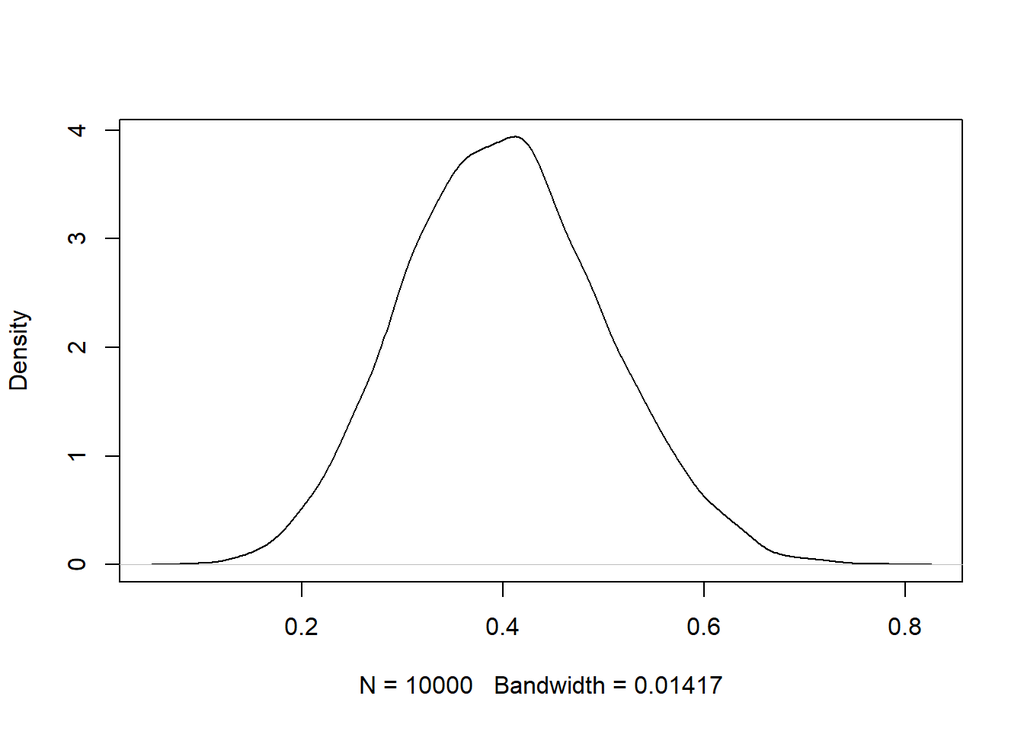

```r
plot(density(beta_check), main="")
```

3. Your Aunt Jo is a successful mushroom hunter. She boasts: *I expect to find enough mushrooms to feed myself and my co-workers at the auto-repair shop 90% of the time, but if I had to give you a likely range it would be between 85% and 95% of the time.*

**Solution**

From the information we have we get

```r
mean = 0.9
variance = (0.1/4)^2
#Now applying the formulas above:
a = (mean *(1-mean)/variance-1)*mean
b = a * (1-mean)/mean

a
```

```
## [1] 128.7
```

```r
b
```

```
## [1] 14.3
```

```r
# Let's check if the mean and variance of the Beta are what we expect
# We can simulate 1000 values from the Beta(a,b) and calculate mean and variance

beta_check = rbeta(1000,a,b)
mean(beta_check)
```

```
## [1] 0.900343
```

```r
var(beta_check)
```

```
## [1] 0.0006384956
```

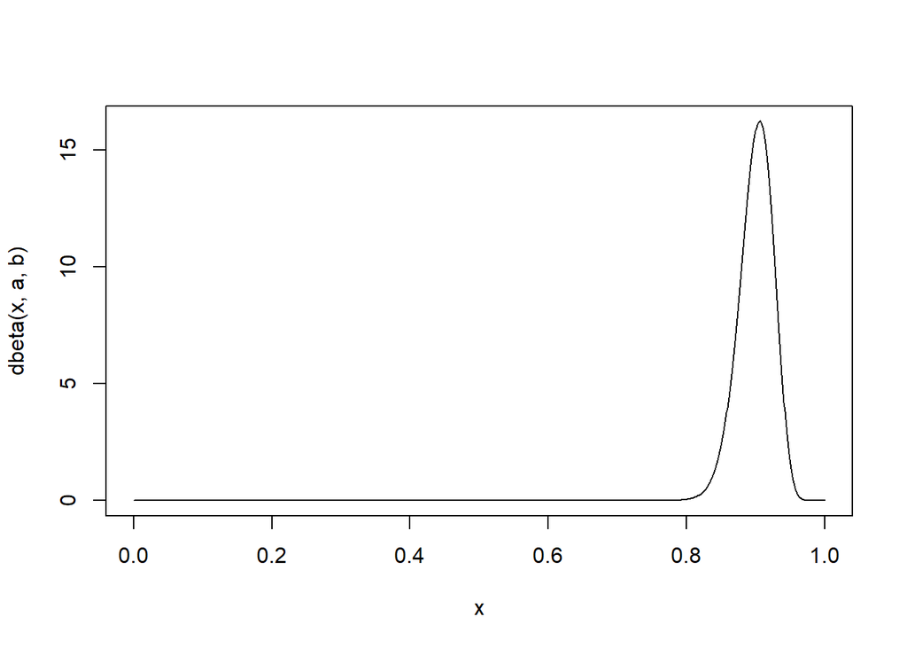

```r
#Now we can plot the probability distribution (using a different function than before)
x=seq(0,1,0.001)
plot(x,dbeta(x,a,b), type="l")
```